# Kristian H. Haugen

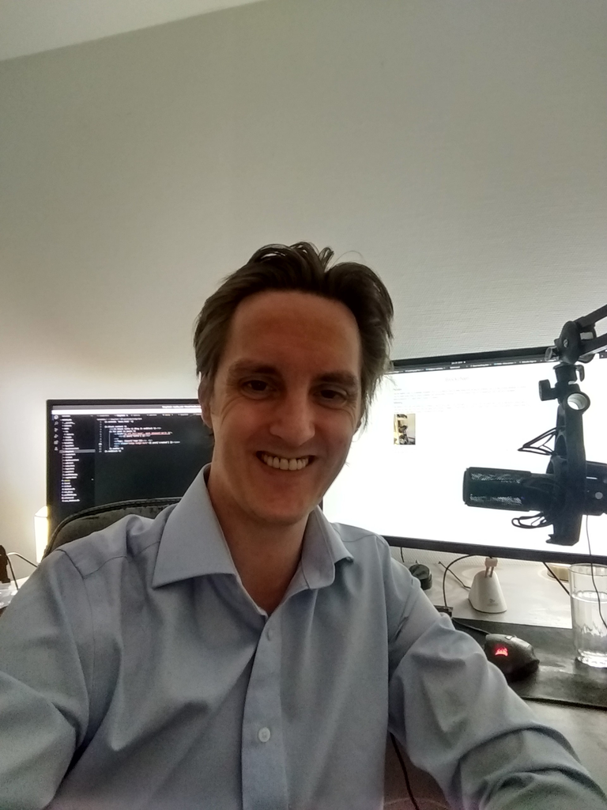

**Statsviter** med særlig interesse for kvantitative forskningsmetoder og statistikk. Undervist samfunnsvitere i kvantitative metoder på universitetet. Gjennomført flere kvantitative analyser, rapporter og fagartikler.

Tromsø, Norge | kr-haugen@hotmail.no | +47 98805153

### Erfaring

**Selvstendig** *Tromsø, Norge | Mars 2022 – Nåværende*

- Utvinning av digital valuta
- Automatisering, drift og vedlikehold av maskiner
- Kjøp og salg av digital valuta

**Universitetslektor** *Stavanger, Norge | Januar 2019 – Juli 2019*

- Foreleser i emnet MEN215 Kvantitativ metode for samfunnsvitere på masternivå
- Sensor

**Universitetslektor** *Tromsø, Norge | August 2016 – Februar 2018*

- Undervisning (hovedsaklig i kvantitative forskningsmetoder)
- Sensur
- Databehandling
- Analyser
- Rapportskriving

**Vitenskapelig assistent** *Tromsø, Norge | Januar 2014 – Desember 2016*

Fire engasjement som vitenskapelig assistent i kvantitative metoder for bachelor og masterstudenter i perioden.

- Undervisning
- Utarbeiding og sensur av arbeidskrav

### Utdanning

**Stipendiat i statsvitenskap** *UiT | 2018 – 2022*

Stipendiatet var tilknyttet prosjektet *[RUR-ED Spatial Inequalities and Spatial Justice in Education](https://site.uit.no/rured/)*. Graden ble ikke fullført.

- Ferdig med pliktarbeidet
- Mangler ett fag for å være ferdig med utdanningsdelen

**Mastergrad i statsvitenskap** *UiT | 2013 – 2015*

Mastergradsoppgave: *[Income inequality, taxation, collective bargaining and trade. A longitudinal analysis of 19 OECD countries in the period 1981-2011](https://munin.uit.no/handle/10037/9094)*.

**Folkehøyskole** *Torshus | 2012 - 2013*

Friluftsliv med paragliding og dykking.

**Bachelor i politisk økonomi** *NTNU | 2009 – 2012*

Bacheloroppgave: Svingvelgermodellen anvendt på lokalisering av kampflybasen.

### Arbeider

- Skolelederforbundet. Forskningsrapport (2021). *[Hva betyr lederskap i skolen?](https://www.skolelederforbundet.no/wp-content/uploads/2021/10/Skolelederforbundets-lederundersokelse_2021.pdf)*
- Local Government Studies (2019): *[Reputation reform strategies in local government: investigating Denmark and Norway](https://www.tandfonline.com/doi/full/10.1080/03003930.2018.1560270?scroll=top&needAccess=true)*. Lockert, Åshild Skjegstad; Bjørnå, Hilde; Haugen, Kristian H.; Salomonsen, Heidi Houlberg.
- Samiske tall forteller 11 (2018): *[Oppslutning om Ap, H, Sp of FrP ved sametingsvalg sammenliknet med stortingsvalg 1989-2017: Er det nasjonale valgvinder eller samepolitikken som teller?](https://munin.uit.no/bitstream/handle/10037/19802/article.pdf?sequence=2&isAllowed=y)* Marcus Buck, Kristian H. Haugen, Jonas Stein og Sigbjørn Svalestuen.
- KS. Evalueringsrapport (2018): *[ETISK REFLEKSJON OG VERDIBEVISSTHET - Betydningen for kvalitet, trivsel og samhandling](https://www.ks.no/contentassets/cb5e2d2285814ef085295bc9c8e10615/Evalueringsrapport-KS-nett.pdf)*.
- Munin (2015): *[Income inequality, taxation, collective bargaining and trade. A longitudinal analysis of 19 OECD countries in the period 1981-2011](https://munin.uit.no/bitstream/handle/10037/9094/thesis.pdf)*

### Konferanser

- European School Head Association Biennial Conference 2022 (Limasol): I want to do something else to be a good leader! A study of everyday life of Norwegian school leaders
- Nasjonal fagkonferanse i statsvitenskap 2020 (Tromsø): National policy and the geographical consequences
- Nordic geographers meeting 2019 (Trondheim): Spatial Variation in School Performance in Norway
- European Society for Rural Sociology Congress 2019 (Trondheim): Spatial Variation in School Performance in Norway

### Ferdigheter

- **Programmeringsspråk**: python
- **Statistikkverktøy**: R, Stata, SPSS
- **Verktøy**: Git

### Språk

- **Norsk**: Morsmål
- **Engelsk**: Flytende

### Interesser

- **Hobbyer**: PC hardware, paragliding, dykking, discgolf, gaming